[figure not shown]

image source (free): https://images.all-free-download.com/images/graphicthumb/beer_312195.jpg

# Data Scientist Exercise: Working with a beer review dataset using Python

Jin-Long Lyu

March 17, 2019

# Introduction

This notebook includes a data analytics report based on the Beer Reviews dataset using Python. In this notebook you will see:

1. Which brewery produces the strongest beers by ABV%?
2. If I had to pick 3 beers to recommend using only this data, which would I pick?
3. Which of the factors (aroma, taste, appearance, palette) are most important in determining the overall quality of a beer?
4. Lastly, if I typically enjoy a beer due to its aroma and appearance, which beer style should I try?

# Beer Reviews Dataset

This tabular data consists of approximately 1.5 million beer reviews from Beer Advocate, and reviewers evaluated beers in term of aroma, appearance, palate and taste in a scale of 0 - 5 points (decimal accepted).

```python
# Unzip file
import tarfile
fname = './beer_reviews/beer_reviews.tar.gz'
tar = tarfile.open(fname, "r:gz")
tar.extractall()
tar.close()
```

# Data at a glance

Showing the firtst 5 rows of data

```python
import pandas as pd
from IPython.display import display,HTML
th_props = [
  ('font-size', '15px'),
  ('text-align', 'center'),
  ('font-weight', 'bold'),
  ('color', '#DF6002'),
  ('background-color', '#F6D08A'),
  ('border-style','solid')
  ]
td_props = [
  ('font-size', '12px'),
  ('font-weight', 'bold'),
#   ('background-color', '#F8E7B9'),
  ('text-align', 'center'),
  ('border-style','dotted')
  ]

styles = [
   dict(selector="tr:hover",props=[("background-color", "#ffff99")]),
  dict(selector="th", props=th_props),
  dict(selector="td", props=td_props)
  ]
df = pd.read_csv("./beer_reviews/beer_reviews.csv",dtype={"brewery_id":object,'beer_beerid':object},encoding='UTF-8')
df.dropna(inplace=True,how='any')
html = (df.head().style.set_table_styles(styles))
print("Table 0.1")
html
```

```
Table 0.1
```

|  | brewery_id | brewery_name | review_time | review_overall | review_aroma | review_appearance | review_profilename | beer_style | review_palate | review_taste | beer_name | beer_abv | beer_beerid |
| --- | --- | --- | --- | --- | --- | --- | --- | --- | --- | --- | --- | --- | --- |
| 0 | 10325 | Vecchio Birraio | 1234817823 | 1.5 | 2 | 2.5 | stcules | Hefeweizen | 1.5 | 1.5 | Sausa Weizen | 5 | 47986 |
| 1 | 10325 | Vecchio Birraio | 1235915097 | 3 | 2.5 | 3 | stcules | English Strong Ale | 3 | 3 | Red Moon | 6.2 | 48213 |
| 2 | 10325 | Vecchio Birraio | 1235916604 | 3 | 2.5 | 3 | stcules | Foreign / Export Stout | 3 | 3 | Black Horse Black Beer | 6.5 | 48215 |
| 3 | 10325 | Vecchio Birraio | 1234725145 | 3 | 3 | 3.5 | stcules | German Pilsener | 2.5 | 3 | Sausa Pils | 5 | 47969 |
| 4 | 1075 | Caldera Brewing Company | 1293735206 | 4 | 4.5 | 4 | johnmichaelsen | American Double / Imperial IPA | 4 | 4.5 | Cauldron DIPA | 7.7 | 64883 |

Information about columns in data

```python
print("Table 0.2")
display(pd.DataFrame(df.dtypes).reset_index().rename(columns={'index':'Column Name',0:'Data Type'}).style.set_table_styles(styles))
```

```
Table 0.2
```

|  | Column Name | Data Type |
| --- | --- | --- |
| 0 | brewery_id | object |
| 1 | brewery_name | object |
| 2 | review_time | int64 |
| 3 | review_overall | float64 |
| 4 | review_aroma | float64 |
| 5 | review_appearance | float64 |
| 6 | review_profilename | object |
| 7 | beer_style | object |
| 8 | review_palate | float64 |
| 9 | review_taste | float64 |
| 10 | beer_name | object |
| 11 | beer_abv | float64 |
| 12 | beer_beerid | object |

# 1. Which brewery produces the strongest beers by ABV%?

### The brewery that produces the strongest beers is Schorschbräu.

Aggregate data by each brewery and get the maximum value of ABV% for each brewery, and then sort this output by each brewery's highest ABV% to find out which brewery produces the strongest beers by ABV%. Finally, we visualize the output by plotting a bar chart showing top 3 brewery with highest ABV% in descending order:

|  | brewery_name | beer_abv |
| --- | --- | --- |
| 0 | Schorschbräu | 57.7 |
| 1 | BrewDog | 41 |
| 2 | De Struise Brouwers | 39 |

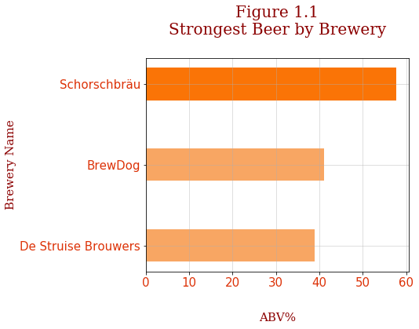

```python
import numpy as np
import matplotlib.pyplot as plt
%matplotlib inline
# Group data by each brewery and get the maximum value of ABV%, and then use this output to find out which brewery produces the strongest beers by ABV%
grouped = df.groupby(['brewery_name'])['beer_abv'].max().sort_values(ascending=True,na_position='first')[-3:]
display(pd.DataFrame(grouped).sort_values(by='beer_abv',ascending=False).reset_index().style.set_table_styles(styles).apply(lambda x : ['background: yellow' if x.name == 0 else '' for i in x],axis=1))
fig1, ax1_1 = plt.subplots(figsize=(6, 5))
abv_max_per_brewery = grouped.values
index = np.array(grouped.index)

rects1 = ax1_1.barh(index, abv_max_per_brewery,height=0.4,color=['#F8A663','#F8A663','#FA7406'])

font = {'family': 'serif',
        'color':  'darkred',
        'weight': 'normal',
        }
ax1_1.set_title('Figure 1.1\nStrongest Beer by Brewery',fontdict=font,fontsize=20,pad=30)
ax1_1.set_ylabel('Brewery Name',fontsize=15,fontdict=font)
ax1_1.set_yticklabels(index,rotation=0,fontsize=15,color='#DC3106')
for item in (ax1_1.get_xticklabels()):
    item.set_fontsize(15)
    item.set_color('#DC3106')
ax1_1.set_xlabel('ABV%',rotation=0,labelpad=30,fontsize=15,fontdict=font)
ax1_1.grid(which='major', alpha=0.5)

plt.show()
```

# 2. Best Beers: Personally Recommended

For me to define the perfect beer that I enjoy drinking the most, I really prefer the one that is not so strong; ideally, 5% to 10% of ABV% is the best. On top of that, the best beer is dominant in terms of overall review score and the popularity (number of reviews), and last but not least, the beer is from the most reputational brewery.

```
My condictions of best beers are shown as the following:
1. Beers ABV% is between 5% to 10% (Fig. 2.1)
2. Popular beers whose number of reviews is 90th percentile and review overall score is 70th percentile (Fig. 2.2)
3. Most reputational brewery whose review overall score is 90th percentile and number of reviews is above average (Fig. 2.3)
```

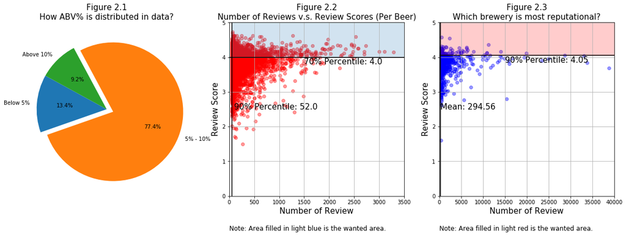

```
--------------------------------------------------------------------------------------------

Generating the list of best beers and selecting top 3 beers (based on review score):

Best Beer No.1 : Armand'4 Oude Geuze Lente (Spring) (Brouwerij Drie Fonteinen)
Best Beer No.2 : Hoppy Birthday (Alpine Beer Company)
Best Beer No.3 : Heady Topper (The Alchemist)

Table 2.1
```

|  | Beer | Brewery | Review Score (Overall) | Beer ABV% |
| --- | --- | --- | --- | --- |
| 0 | Armand'4 Oude Geuze Lente (Spring) | Brouwerij Drie Fonteinen | 4.73 | 6 |
| 1 | Hoppy Birthday | Alpine Beer Company | 4.68 | 5.25 |
| 2 | Heady Topper | The Alchemist | 4.63 | 8 |

```python
print("My condictions of best beers are shown as the following:")
# get a list of beers whose ABV% is between 5% to 10%
lower_abv,higher_abv = 5,10
cond1_beers = df.where(df['beer_abv']>=lower_abv).where(df['beer_abv']<=higher_abv)
print("1. Beers ABV% is between {}% to {}% (Fig. 2.1)".format(lower_abv,higher_abv))

# get a list of beers whose review count is higher than the data population average
p2_c,p2_m=90,70
aggregated2 = df.reset_index().groupby(['brewery_name','beer_name','beer_abv'])['review_overall'].agg({'count','mean'}).round(2)
threshold2_c,threshold2_m = np.percentile(aggregated2['count'],p2_c),np.percentile(aggregated2['mean'],p2_m)
aggregated2 = aggregated2.where(aggregated2['count']>threshold2_c).dropna()
cond2_beers = aggregated2.where(aggregated2['mean']>threshold2_m ).dropna().reset_index()
print("2. Popular beers whose number of reviews is {}th percentile and review overall score is {}th percentile (Fig. 2.2)".format(p2_c,p2_m))

# get a list of reputational brewery that have above-average review counts (popularity) and its average review scores is among the top 10% in the population
p3 = 90
aggregated3 = df.groupby(['brewery_name'])['review_overall'].agg({"mean","count"}).round(2)
threshold3_c,threshold3_m = np.mean(aggregated3['count']),np.percentile(aggregated3['mean'],p3)
aggregated3 = aggregated3.where(aggregated3['count']>threshold3_c).dropna()
reputational_brewery = aggregated3.where(aggregated3['mean']>threshold3_m ).dropna().index
print("3. Most reputational brewery whose review overall score is {}th percentile and number of reviews is above average (Fig. 2.3)".format(p3))

# plot
fig2 = plt.figure(figsize=(20, 6))
# Figure 2.1
ax2_1 = fig2.add_subplot(131)
ratios = [df.where(df['beer_abv']<lower_abv)[['brewery_name','beer_name']].dropna().shape[0]/np.float(df.shape[0]),\
          cond1_beers.dropna().shape[0]/np.float(df.shape[0]),\
          df.where(df['beer_abv']>higher_abv)[['brewery_name','beer_name']].dropna().shape[0]/np.float(df.shape[0])]
labels = ['Below 5%', '5% - 10%', 'Above 10%']
explode = [0, 0.1, 0]
# rotate so that first wedge is split by the x-axis
angle = -270 * ratios[1]
ax2_1.pie(ratios, autopct='%1.1f%%', startangle=angle,
        labels=labels, explode=explode)
ax2_1.set_title('Figure 2.1\nHow ABV% is distributed in data?',fontsize=15)

# Figure 2.2
ax2_2 = fig2.add_subplot(132)
ax2_2.scatter(aggregated2['count'],aggregated2['mean'], marker='o',alpha=0.4,c='r')
ax2_2.set_title('Figure 2.2\nNumber of Reviews v.s. Review Scores (Per Beer)',fontsize=15)
ax2_2.set_ylabel('Review Score',fontsize=15)
ax2_2.set_xlabel('Number of Review',fontsize=15)
ax2_2.axvline(threshold2_c, color="black")
ax2_2.text(threshold2_c+50,2.5,'{}% Percentile: '.format(p2_c)+str(round(threshold2_c,2)),fontsize=15)
ax2_2.axhline(threshold2_m, color="black")
ax2_2.text(1500,threshold2_m-0.2,'{}% Percentile: '.format(p2_m)+str(round(threshold2_m,2)),fontsize=15)
ax2_2.fill_between(np.array([threshold2_c,3500]),threshold2_m,5,alpha=0.2)
ax2_2.set_xlim(0,3500)
ax2_2.set_ylim(0,5)
ax2_2.grid(True)
ax2_2.text(0,-1,'Note: Area filled in light blue is the wanted area.',fontsize=12)

# Figure 2.3
ax2_3 = fig2.add_subplot(133)
ax2_3.set_title('Figure 2.3\nWhich brewery is most reputational?',fontsize=15)
ax2_3.scatter(aggregated3['count'],aggregated3['mean'], marker='o',alpha=0.4,c='b')
ax2_3.set_ylabel('Review Score',fontsize=15)
ax2_3.set_xlabel('Number of Review',fontsize=15)
ax2_3.axvline(threshold3_c, color="black")
ax2_3.text(threshold3_c+50,2.5,'Mean: '+str(round(threshold3_c,2)),fontsize=15)
ax2_3.axhline(threshold3_m, color="black")
ax2_3.text(15000,threshold3_m-0.2,'{}% Percentile: '.format(p3)+str(round(threshold3_m,2)),fontsize=15)
ax2_3.fill_between(np.array([threshold3_c,40000]),threshold3_m,5,alpha=0.2,color='r')
ax2_3.set_xlim(0,40000)
ax2_3.set_ylim(0,5)
ax2_3.grid(True)
ax2_3.text(0,-1,'Note: Area filled in light red is the wanted area.',fontsize=12)
plt.show()

print("\n--------------------------------------------------------------------------------------------\n\nGenerating the list of best beers and selecting top 3 beers (based on review score):\n")
# use the previously sorted list from condition 2 (cond2_beers) to select the first (highest in review overall score) 3 beers that satistify all conditions above
beers = cond2_beers.reset_index().sort_values(by=['mean','count'],ascending=False)
recommenedBeers = []
recommenedBeersDF = pd.DataFrame(columns=['Beer','Brewery','Review Score (Overall)','Beer ABV%'])
x = len(recommenedBeers)
idx = 0
while x != 3 and idx <= beers.shape[0]-1:
    beer = beers.reset_index().loc[idx,'beer_name']
    brewery = beers.reset_index().loc[idx,'brewery_name']
    if brewery in reputational_brewery and beer in cond1_beers['beer_name'].unique():
        s = "{} ({})".format(beer,brewery)
        print("Best Beer No.{} : {}".format(x+1,s))
        recommenedBeers.append(s)
        recommenedBeersDF.loc[x,:]=np.array(beers.reset_index().loc[idx,['beer_name','brewery_name','mean','beer_abv']])
        x = len(recommenedBeers)

    idx += 1
# Visualizing the output table

print("\nTable 2.1")
display(recommenedBeersDF.style.set_table_styles(styles).apply(lambda x : ['background: yellow' if x.name == 0 else '' for i in x],axis=1))
```

# 3. Which of the factors (aroma, taste, appearance, palette) are most important in determining the overall quality of a beer?

In terms of a good quality of a beer, let's assume the review overall score in data represents the overall quality of beers. Now that we already have data representing the overall quality of beers, the next thing that we are wondering now is that which one of these factors(aroma, taste, appearance & palette) is most important in affecting the scoring of the review overall variable (dependent variable).

One way to figure out the relationships between each of thsee variables and its dependent variable, we can fit a linear regression model and compare some of the crucial statistics, such as R-squared and regression coefficients, to find out the answer for us.

### Method 1: Comparing the coefficients

After fitting a linear regression model, we can observe that review_taste has the highest values of coefficient among all variables, which implies that review_taste is the most important variable in determining the values of the review overall score; in other words, it is the most important factor in determining a good quality of a beer.

Result: taste -> palate -> appearance -> aroma (importance from high to low)

```python
from statsmodels.api import OLS
x = df[['review_aroma', 'review_appearance','review_palate', 'review_taste']]
y = df[['review_overall']]
model = OLS(y, x)
result = model.fit()
print(result.summary())
```

```
                            OLS Regression Results
==============================================================================
Dep. Variable:         review_overall   R-squared:                       0.988
Model:                            OLS   Adj. R-squared:                  0.988
Method:                 Least Squares   F-statistic:                 3.117e+07
Date:                Mon, 18 Mar 2019   Prob (F-statistic):               0.00
Time:                        04:04:26   Log-Likelihood:            -8.6170e+05
No. Observations:             1518478   AIC:                         1.723e+06
Df Residuals:                 1518474   BIC:                         1.723e+06
Df Model:                           4
Covariance Type:            nonrobust
=====================================================================================
                        coef    std err          t      P>|t|      [0.025      0.975]
-------------------------------------------------------------------------------------
review_aroma          0.0695      0.001     93.864      0.000       0.068       0.071
review_appearance     0.0968      0.001    149.641      0.000       0.096       0.098
review_palate         0.2842      0.001    366.704      0.000       0.283       0.286
review_taste          0.5559      0.001    690.956      0.000       0.554       0.557
==============================================================================
Omnibus:                    89231.687   Durbin-Watson:                   1.742
Prob(Omnibus):                  0.000   Jarque-Bera (JB):           391812.465
Skew:                           0.048   Prob(JB):                         0.00
Kurtosis:                       5.487   Cond. No.                         22.4
==============================================================================

Warnings:
[1] Standard Errors assume that the covariance matrix of the errors is correctly specified.
```

note: in order to ensure we can compare the coefficients without problem, we need to know that aroma, taste, appearance, palette and overall score use the same scale (0 to 5).

### Method 2: Comparing the Values of R-Squared

We can also identify the most important feature by looking at the increase in R-squared when each variable is added to a model that already contains all of the other variables. It is obvious that review_taste has the highest increase in R-squared, which can be interpreted that it is the most important variable in determining good qaulity of beers just like method 1.

Result: taste -> palate -> appearance -> aroma (importance from high to low)

```python
# Create a empty dataframe for storing output
r2_df = pd.DataFrame(columns=['Variable','R-Squared With All Other Variables','R-Squared Incresae'])
# calculate the r^2 with ALL variables fitted to linear regression model
r2 = result.rsquared
# calculate the r^2 with EACH of variable excluded from linear regression model
for idx,variable in enumerate(x.columns):
    new_x = x.drop(variable,axis=1)
    new_model = OLS(y, new_x)
    new_result = new_model.fit()
    r2_df.loc[idx,:]=[variable,np.round(new_result.rsquared,4),np.round(r2 - new_result.rsquared,4)]
print("Table 3.1")
display(r2_df.sort_values(by= 'R-Squared Incresae',ascending=False).style.set_table_styles(styles).apply(lambda x : ['background: yellow' if x.name == 3 else '' for i in x],axis=1))
```

```
Table 3.1
```

|  | Variable | R-Squared With All Other Variables | R-Squared Incresae |
| --- | --- | --- | --- |
| 3 | review_taste | 0.9842 | 0.0038 |
| 2 | review_palate | 0.9869 | 0.0011 |
| 1 | review_appearance | 0.9878 | 0.0002 |
| 0 | review_aroma | 0.9879 | 0.0001 |

# 4. Lastly, if I typically enjoy a beer due to its aroma and appearance, which beer style should I try?

Let's assume if a beer has the best aroma and appearance scores, then it'd score high in the review data (specifically review_aroma and review_appearance), and we can then compute the combined score of aroma and appearance by taking their mean. After sorting the result, it is observed that American Double / Imperial Stout is the most ideal beer style to try for it has the highest combined score of aroma and appearance.

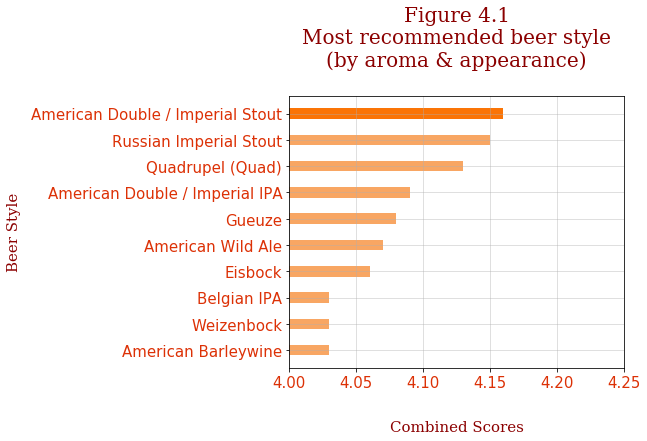

```
Table 4.1
```

| beer_style | review_aroma | review_appearance | Combined Scores |
| --- | --- | --- | --- |
| American Double / Imperial Stout | 4.161 | 4.164 | 4.1625 |
| Russian Imperial Stout | 4.078 | 4.213 | 4.1455 |
| Quadrupel (Quad) | 4.134 | 4.12 | 4.127 |
| American Double / Imperial IPA | 4.1 | 4.081 | 4.0905 |
| Gueuze | 4.117 | 4.038 | 4.0775 |
| American Wild Ale | 4.135 | 4.011 | 4.073 |
| Eisbock | 4.157 | 3.963 | 4.06 |
| Belgian IPA | 3.984 | 4.081 | 4.0325 |
| Weizenbock | 4.05 | 4.013 | 4.0315 |
| American Barleywine | 4.022 | 4.04 | 4.031 |

```python
# First, group the data by beer style and compute its each average score of roma and appearance
bs_df = df.groupby(['beer_style'])['review_aroma', 'review_appearance'].mean().round(3)
# Calculate the combined score of aroma and appearance
bs_df['Combined Scores'] = (bs_df['review_aroma'] + bs_df['review_appearance'])/2.0


# visualize the result
fig4, ax4_1 = plt.subplots(figsize=(6, 5))
Combined_Scores = np.round(bs_df['Combined Scores'].sort_values()[-10:].values,2)
index = np.array(bs_df.sort_values(by='Combined Scores')[-10:].index)
font = {'family': 'serif',
        'color':  'darkred',
        'weight': 'normal',
        }
colors = list(['#F8A663']*9)
colors.append('#FA7406')
ax4_1.barh(index,Combined_Scores,height=0.4,color=colors)

for item in (ax4_1.get_xticklabels()+ax4_1.get_yticklabels()):
    item.set_fontsize(15)
    item.set_color('#DC3106')

ax4_1.set_xlabel('Combined Scores',labelpad=30,fontsize=15,fontdict=font)
ax4_1.set_ylabel('Beer Style',labelpad=10,fontsize=15,fontdict=font)
ax4_1.set_title('Figure 4.1\nMost recommended beer style\n(by aroma & appearance)',fontdict=font,fontsize=20,pad=30)
ax4_1.set_xlim(4,4.25)
ax4_1.grid(which='major', alpha=0.5)
plt.show()
print("\nTable 4.1")
display(bs_df.sort_values(by=['Combined Scores'],ascending=False)[:10].style.set_table_styles(styles).apply(lambda x : ['background: yellow' if x.name == 'American Double / Imperial Stout' else '' for i in x],axis=1))
```